# Reproducible Research: Peer Assessment 1

## Introduction

In this assignment for Coursera's Reproducible Research class, data from a personal activity monitoring deviced is going to be analyzed. The device collects data at 5 minute intervals through out the day. The data consists of two months of data from an anonymous individual collected during the months of October and November, 2012 and include the number of steps taken in 5 minute intervals each day.

## Loading and preprocessing the data

First of all, the activity.csv file is read from the activity.zip file provided by this assignment's git repository and it's date variable is converted to R's native date object.

```r
data <- read.csv(unz("./activity.zip", "activity.csv"))
data$date <- as.Date(data$date, format = "%Y-%m-%d")
```

## What is mean total number of steps taken per day?

To see the distribuition of steps taken by day, the number of steps taken each day must be aggregated before drawing the histogram.

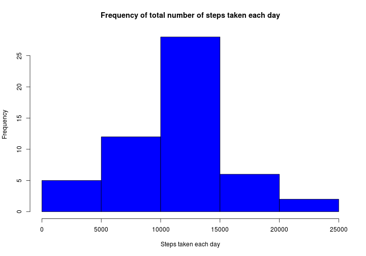

```r
stepsByDay <- aggregate(. ~ date, data = data, sum)
hist(stepsByDay[, 2], main = "Frequency of total number of steps taken each day",
    col = "blue", xlab = "Steps taken each day")
```

Then the mean and median are then calculated:

```r
mean(stepsByDay[, 2], na.rm = TRUE)
```

```
## [1] 10766
```

```r
median(stepsByDay[, 2], na.rm = TRUE)
```

```
## [1] 10765
```

## What is the average daily activity pattern?

In order to display the average daily activity pattern, the number of steps average is taken, grouped by interval.

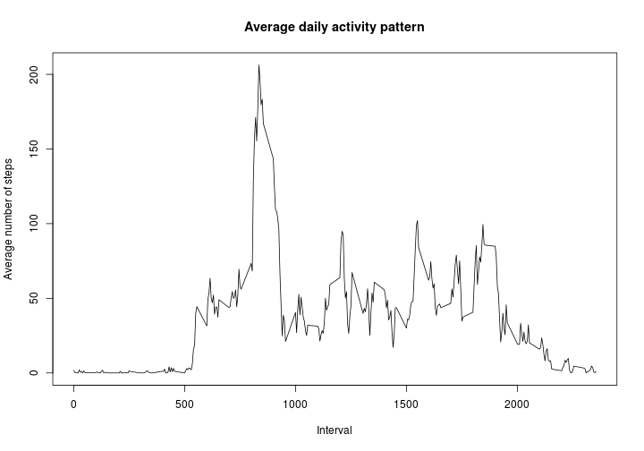

```r
avgByInterval <- aggregate(steps ~ interval, data = data[, c(1, 3)], mean)
plot(avgByInterval$interval, avgByInterval$steps, type = "l", xlab = "Interval",
    ylab = "Average number of steps", main = "Average daily activity pattern")
```

The interval with the highest average number of steps is:

```r
avgByInterval[avgByInterval$steps == max(avgByInterval$steps), ][, 1]
```

```
## [1] 835
```

## Imputing missing values

The data set has the following number of missing values:

| Row | # missing values |
| --- | --- |
| Steps | 2304 |
| Date | 0 |
| Interval | 0 |

This means there are 2304 rows with missing values in the data set. We could complete those values by using the mean for that interval.

```r
all <- merge(data, avgByInterval, by.x = "interval", by.y = "interval")
all$steps <- ifelse(is.na(all$steps.x), all$steps.y, all$steps.x)
all <- all[, c("steps", "date", "interval")]
```

And here is a histogram of steps taken by day, the number of steps taken each day must be aggregated before drawing the histogram.

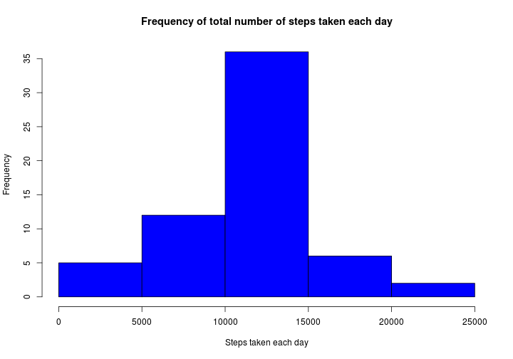

```r
stepsByDay <- aggregate(. ~ date, data = all, sum)
hist(stepsByDay[, 2], main = "Frequency of total number of steps taken each day",
    col = "blue", xlab = "Steps taken each day")
```

Then the new mean and median are calculated:

```r
mean(stepsByDay[, 2], na.rm = TRUE)
```

```
## [1] 10766
```

```r
median(stepsByDay[, 2], na.rm = TRUE)
```

```
## [1] 10766
```

The mean is the same that the one calculated by ignoring the missing values but the median is sligtly different. Having replaced missing values with averages makes the distribution to grow in it's center as the new considered values correspond to averages.

## Are there differences in activity patterns between weekdays and weekends?

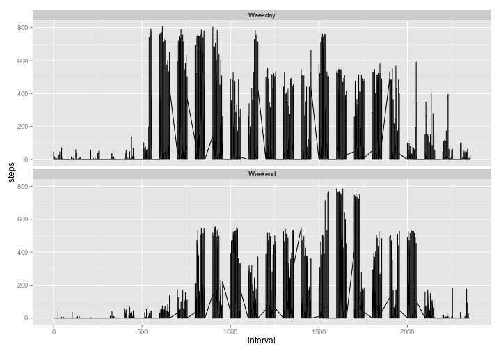

```r
all$dayType <- ifelse(weekdays(all$date) %in% c("Saturday", "Sunday"), "Weekend",
    "Weekday")
library(ggplot2)
ggplot(all, aes(x = interval, y = steps)) + geom_line() + facet_wrap(~dayType,
    nrow = 2)
```